# Setting up your R Environment

1. Follow the instructions in chapters 4-6 at https://happygitwithr.com/ to create a GitHub account, install R and RStudio.
2. Open RStudio.
3. Follow instructions in this video to ensure git is installed:

[Verify Git Installation](https://vimeo.com/511798611) from [David Keyes](https://vimeo.com/user95475944) on [Vimeo](https://vimeo.com).

4. If git is not installed, follow instructions in chapter 7 at https://happygitwithr.com/
5. Edit your git config by following these instructions:

[Edit gitconfig file](https://vimeo.com/511798861) from [David Keyes](https://vimeo.com/user95475944) on [Vimeo](https://vimeo.com).

6. Create a personal access token by following these instructions:

[Create a Personal Access Token (PAT) on GitHub](https://vimeo.com/511801645) from [David Keyes](https://vimeo.com/user95475944) on [Vimeo](https://vimeo.com).

7. Store your personal access token by following these instructions:

[Store Personal Access Token to Connect RStudio and GitHub](https://vimeo.com/511803103) from [David Keyes](https://vimeo.com/user95475944) on [Vimeo](https://vimeo.com).

8. Copy the URL for this portfolio GitHub repo. It should look like this: https://github.com/SDS-237-Data-Ethnography-Spring-22/portfolio-YOUR_USER_NAME
9. Create a project in RStudio from this GitHub repo by following the instructions starting at 26 seconds of this video:

[How to Connect RStudio Projects with GitHub Repositories: GitHub First](https://vimeo.com/511804881) from [David Keyes](https://vimeo.com/user95475944) on [Vimeo](https://vimeo.com).

10. Install the rmarkdown package in RStudio by entering the following lines of code in the Console Pane of RStudio (lower left hand corer on initial install).

```
install.packages("rmarkdown")
library(rmarkdown)
```

[figure not shown]

RStudio Panels

11. In the Environment panel (upper right hand corner), click on the Git tab. The branch will be set to main (see image below). Add a new branch by clicking the icon with two purple boxes (See image below.) Name your branch yourinitials-getting-started (e.g. Lindsay’s would be lp-getting-started). Make sure you are in your branch (i.e. where it used to say ‘main’, it will now have your branch name).

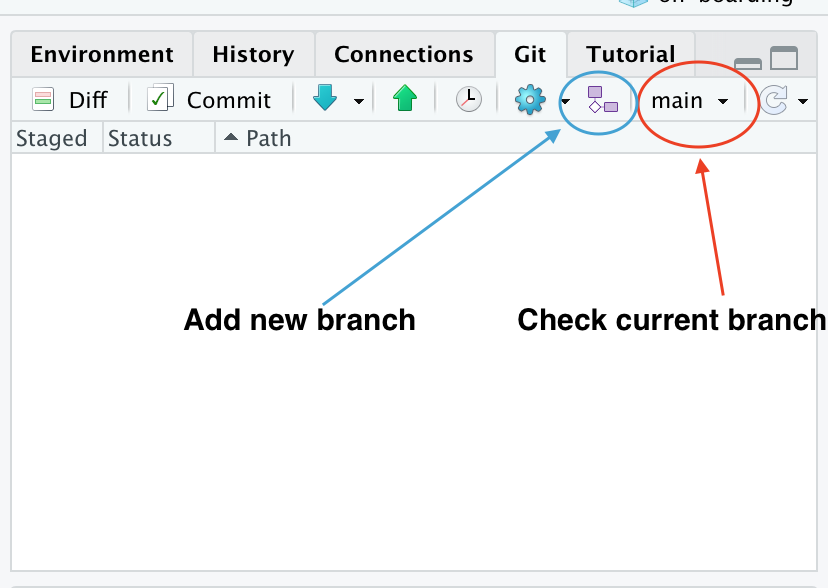

Git Panel/Branching

12. On the initial install, the Files tab will be in the lower right hand corner of RStudio. Open the setting-up-r-environment folder, and then open getting-started.Rmd, and follow instructions.
13. When the file tells you to commit your code, follow the instructions in this video starting at 14 seconds:

[Make a Commit and View More History](https://vimeo.com/511800674) from [David Keyes](https://vimeo.com/user95475944) on [Vimeo](https://vimeo.com).

15. Push your code to GitHub.com by following the instructions in this video starting at 27 seconds:

[General Workflow: Push](https://vimeo.com/511805399) from [David Keyes](https://vimeo.com/user95475944) on [Vimeo](https://vimeo.com).

16. Navigate to https://github.com/SDS-237-Data-Ethnography-Spring-22/portfolio-YOUR_USER_NAME and click on the Pull Requests tab. Click New Pull Request. Where the button says ‘base:’ make sure ‘main’ is selected. Where the button says ‘compare:’ make sure your branch is selected. Click Create Pull Request.